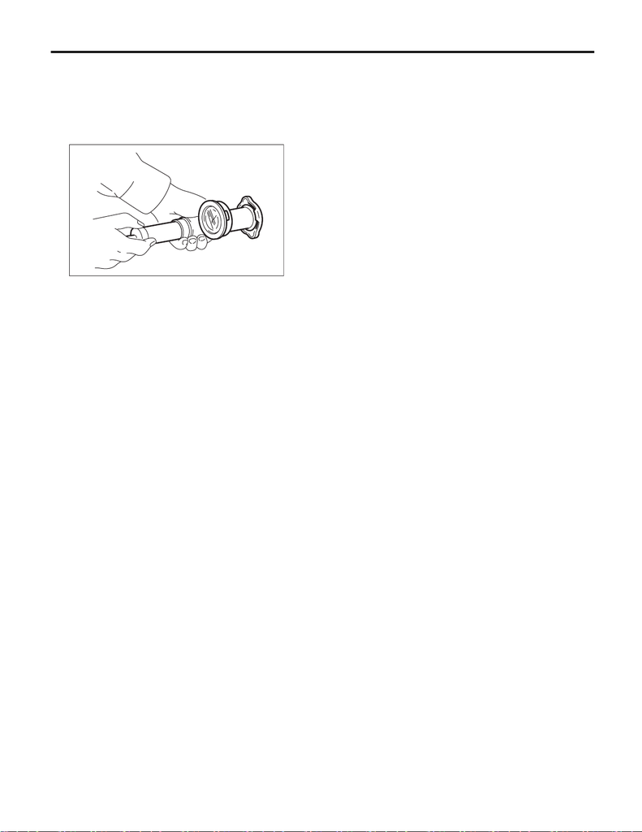

Radiator Cap

COOLING

7. Radiator Cap

A: INSPECTION

1) Check that the radiator cap does not have defor-

mation, cracks or damage.

2) Attach the radiator cap tester to radiator cap.

3) Increase pressure until the radiator cap tester

gauge needle stops. Radiator cap is functioning

properly if it holds the service limit pressure for 5 —

6 seconds. Replace the radiator cap if its valve

opens at less than the service limit.

Coolant filler tank side:

Standard

93 — 123 kPa (0.95 — 1.25 kg/cm

, 14 — 18

psi)

Limit

83 kPa (0.85 kg/cm

, 12 psi)

Radiator side:

Standard

122 — 152 kPa (1.24 — 1.55 kg/cm

, 18 —

22 psi)

Limit

112 kPa (1.14 kg/cm

, 16 psi)

CAUTION:

• Be sure to remove foreign matter and rust

from the cap in advance. Otherwise, results of

pressure test will be incorrect.

• Do not confuse the cap of coolant filler tank

and cap of radiator.